# GitHub Analytics

Analyzing the GitHub Developer Network

Author

Farhan Sadeek

Published

March 8, 2026

# Abstract

This project analyzes the GitHub social network distributed with the MUSAE project. The data contain 37,700 developers and 289,003 undirected edges representing mutual-follower relationships. Each developer is labeled as either a Web Developer or a Machine Learning Engineer based on the developer’s job title. The analysis examines graph connectivity, hubs, degree distributions, centrality, communities, assortativity, random-graph comparisons, and small-world structure.

# 1 Introduction

## 1.1 Motivation and importance

GitHub is a major platform for hosting and sharing open-source software (Hague 2022). A public GitHub profile can function as a portfolio, while follower relationships provide a useful lens for studying visibility, influence, and the organization of the software-development community.

## 1.2 Prior work

The data were released as part of the MUSAE project and are hosted by the [Stanford Network Analysis Project](https://snap.stanford.edu/data/github-social.html). MUSAE is an attributed node-embedding method designed for node-classification tasks (Rozemberczki, Allen, and Sarkar 2021). This report applies classical graph-analysis methods to the same developer network, following the workflow described by Kolaczyk and Csárdi (2020).

## 1.3 Limitations

The network is a snapshot collected in June 2019, so it does not represent the present-day developer ecosystem. Its binary job-title label omits many occupations, and mutual followers capture only one form of interaction: shared repositories, commits, reviews, issues, and other collaborative activity are absent. The inclusion rule also favors visible developers, because every developer in the source data had starred at least ten repositories.

# 2 Data

## 2.1 Source and construction

The structural and attribute data are stored separately:

- `musae_git_edges.csv` contains the undirected edge list.
- `musae_git_target.csv` contains numeric node IDs, usernames, and the binary `ml_target` label.

```r
# Load the two source files.
edges <- read_csv("musae_git_edges.csv", show_col_types = FALSE)
developers <- read_csv("musae_git_target.csv", show_col_types = FALSE)

# igraph expects the vertex key in a column named `name`. Preserve the
# human-readable GitHub username in a separate `developer` attribute.
vertices <- developers |>
  rename(developer = name) |>
  transmute(
    name = as.character(id),
    developer,
    ml_target = as.integer(ml_target)
  )

github_graph <- graph_from_data_frame(
  edges,
  directed = FALSE,
  vertices = vertices
) |>
  simplify(remove.multiple = TRUE, remove.loops = TRUE)

degree_all <- degree(github_graph)
component_info <- components(github_graph)
core_number <- coreness(github_graph)
```

## 2.2 Validation and overview

```r
overview <- tibble(
  Nodes = vcount(github_graph),
  Edges = ecount(github_graph),
  Density = edge_density(github_graph),
  Components = component_info$no,
  Simple = is_simple(github_graph),
  Directed = is_directed(github_graph),
  `Maximum k-core` = max(core_number)
)

kable(
  overview,
  digits = 6,
  caption = "Observed properties of the GitHub mutual-follower network."
)
```

Observed properties of the GitHub mutual-follower network.

| Nodes | Edges | Density | Components | Simple | Directed | Maximum k-core |
| --- | --- | --- | --- | --- | --- | --- |
| 37700 | 289003 | 0.000407 | 1 | TRUE | FALSE | 34 |

The graph is simple, undirected, globally connected, and sparse. Its density is only about $4.07 \times 10^{-4}$, even though all 37,700 developers belong to one connected component.

```r
label_balance <- developers |>
  count(ml_target, name = "Count") |>
  mutate(
    Label = if_else(ml_target == 0, "Web (0)", "MLE (1)"),
    Percent = percent(Count / sum(Count), accuracy = 0.1)
  ) |>
  select(Label, Count, Percent)

kable(label_balance, caption = "Distribution of developer-type labels.")
```

Distribution of developer-type labels.

| Label | Count | Percent |
| --- | --- | --- |
| Web (0) | 27961 | 74.2% |
| MLE (1) | 9739 | 25.8% |

Web Developers account for 74.2% of the nodes, while Machine Learning Engineers account for 25.8%. This is a node attribute on an ordinary graph, not a bipartite structure: both kinds of developers can connect to either kind.

# 3 Methods and analysis

All graph operations use the R `igraph` package (Csardi and Nepusz 2006). The analysis code is displayed in full throughout the page with line numbers and copy controls.

## 3.1 Top hub nodes

```r
top_hubs <- tibble(
  `Node ID` = as.integer(V(github_graph)$name),
  Developer = V(github_graph)$developer,
  Degree = degree_all,
  Label = if_else(V(github_graph)$ml_target == 0, "Web", "MLE")
) |>
  arrange(desc(Degree)) |>
  slice_head(n = 15) |>
  mutate(Rank = row_number(), .before = 1)

kable(top_hubs, format.args = list(big.mark = ","),
      caption = "Top 15 developers by mutual-follower degree.")
```

Top 15 developers by mutual-follower degree.

| Rank | Node ID | Developer | Degree | Label |
| --- | --- | --- | --- | --- |
| 1 | 31,890 | dalinhuang99 | 9,458 | Web |
| 2 | 27,803 | nfultz | 7,085 | Web |
| 3 | 35,773 | addyosmani | 3,324 | Web |
| 4 | 19,222 | Bunlong | 2,958 | Web |
| 5 | 13,638 | gabrielpconceicao | 2,468 | Web |
| 6 | 36,652 | rfthusn | 2,343 | Web |
| 7 | 18,163 | nelsonic | 1,924 | Web |
| 8 | 9,051 | getify | 1,797 | Web |
| 9 | 35,008 | mdo | 1,571 | Web |
| 10 | 10,001 | ronenhamias | 1,568 | Web |
| 11 | 36,628 | SuriyaaKudoIsc | 1,507 | Web |
| 12 | 7,027 | jeresig | 1,485 | Web |
| 13 | 19,253 | JonnyBanana | 1,404 | Web |
| 14 | 2,078 | mbostock | 1,368 | Web |
| 15 | 33,671 | shayan-taheri | 1,347 | Web |

The highest-degree nodes are all labeled Web Developers. The concentration around developers such as `addyosmani`, `getify`, `mdo`, `jeresig`, and `mbostock` is consistent with the visibility of web tooling and education in the 2019 GitHub ecosystem.

## 3.2 Degree distribution

```r
degree_summary <- tibble(
  Statistic = c("Minimum", "First quartile", "Median", "Mean",
                "Third quartile", "90th percentile", "99th percentile", "Maximum"),
  Degree = c(
    min(degree_all),
    quantile(degree_all, 0.25),
    median(degree_all),
    mean(degree_all),
    quantile(degree_all, 0.75),
    quantile(degree_all, 0.90),
    quantile(degree_all, 0.99),
    max(degree_all)
  )
)

kable(degree_summary, digits = 2, caption = "Degree-distribution summary.")
```

Degree-distribution summary.

| Statistic | Degree |
| --- | --- |
| Minimum | 1.00 |
| First quartile | 2.00 |
| Median | 6.00 |
| Mean | 15.33 |
| Third quartile | 13.00 |
| 90th percentile | 30.00 |
| 99th percentile | 138.01 |
| Maximum | 9458.00 |

The median degree is 6, whereas the mean is 15.33 and the maximum is 9,458. The large gap between the center and the upper tail reveals a strongly right-skewed network dominated by a small set of hubs.

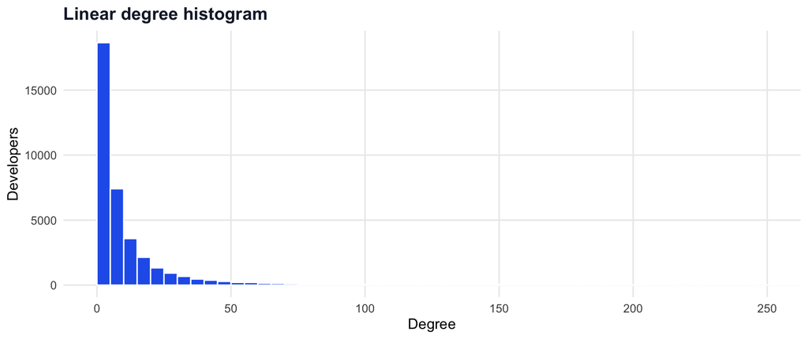

Degree distribution on linear and logarithmic scales. The linear panel shows the concentration of low-degree nodes; the log-log complementary cumulative distribution shows the long upper tail.

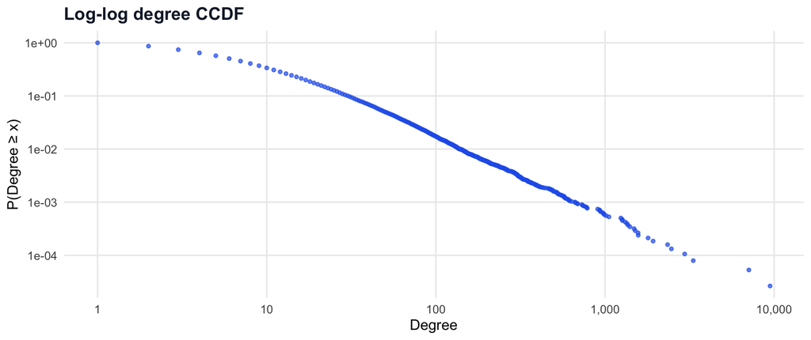

Degree distribution on linear and logarithmic scales. The linear panel shows the concentration of low-degree nodes; the log-log complementary cumulative distribution shows the long upper tail.

```r
degree_plot_data <- tibble(degree = degree_all)

ggplot(degree_plot_data, aes(degree)) +
  geom_histogram(binwidth = 5, boundary = 0, fill = web_color, color = "white") +
  coord_cartesian(xlim = c(0, 250)) +
  labs(title = "Linear degree histogram", x = "Degree", y = "Developers")
degree_ccdf <- degree_plot_data |>
  count(degree, name = "frequency") |>
  arrange(degree) |>
  mutate(ccdf = rev(cumsum(rev(frequency))) / sum(frequency))

ggplot(degree_ccdf, aes(degree, ccdf)) +
  geom_point(size = 1.2, alpha = 0.7, color = web_color) +
  scale_x_log10(labels = label_number(big.mark = ",")) +
  scale_y_log10() +
  labs(title = "Log-log degree CCDF", x = "Degree", y = "P(Degree ≥ x)")
```

The upper tail is compatible with a heavy-tailed or preferential-attachment process. A straight-looking region in a log-log plot is suggestive, but it is not by itself sufficient evidence that the data follow an exact power law.

## 3.3 Vertex centrality

Centrality measures describe different kinds of structural importance. Degree captures immediate reach; betweenness identifies bridges; closeness captures network-wide reachability; and eigenvector centrality rewards connections to other well-connected nodes.

```r
# Exact full-network centralities are intentionally not recalculated during
# every website build. Enable this chunk to reproduce them; it can take several
# minutes depending on the igraph version and build machine.
centrality <- tibble(
  degree = degree(github_graph, normalized = TRUE),
  betweenness = betweenness(github_graph, normalized = TRUE),
  closeness = closeness(github_graph, normalized = TRUE),
  eigenvector = eigen_centrality(github_graph)$vector
)

summary(centrality)
cor(centrality, use = "complete.obs")
```

```r
centrality_summary <- tribble(
  ~Statistic, ~Degree, ~Betweenness, ~Closeness, ~Eigenvector,
  "Minimum",       0.00002653, 0.000000001, 0.1414, 0.0000000,
  "First quartile",0.00005305, 0.000000045, 0.2841, 0.0004698,
  "Median",        0.0001592,  0.000001529, 0.3113, 0.0030462,
  "Mean",          0.0004067,  0.000059592, 0.3137, 0.0066687,
  "Third quartile",0.0003448,  0.000017282, 0.3469, 0.0089577,
  "Maximum",       0.2509689,  0.269626963, 0.5231, 1.0000000
)

kable(centrality_summary, digits = 8,
      caption = "Summary statistics reported for full-network centrality measures.")
```

Summary statistics reported for full-network centrality measures.

| Statistic | Degree | Betweenness | Closeness | Eigenvector |
| --- | --- | --- | --- | --- |
| Minimum | 0.00002653 | 0.00000000 | 0.1414 | 0.0000000 |
| First quartile | 0.00005305 | 0.00000004 | 0.2841 | 0.0004698 |
| Median | 0.00015920 | 0.00000153 | 0.3113 | 0.0030462 |
| Mean | 0.00040670 | 0.00005959 | 0.3137 | 0.0066687 |
| Third quartile | 0.00034480 | 0.00001728 | 0.3469 | 0.0089577 |
| Maximum | 0.25096890 | 0.26962696 | 0.5231 | 1.0000000 |

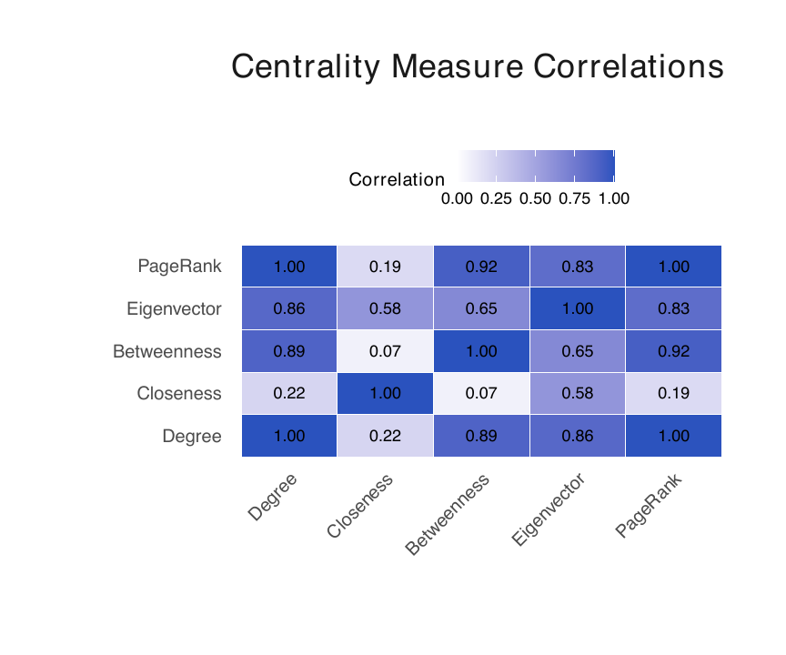

Figure 1: Correlation among the full-network centrality measures.

## 3.4 Components, transitivity, and clustering

```r
cohesion <- tibble(
  Components = component_info$no,
  Nodes = vcount(github_graph),
  Edges = ecount(github_graph),
  `Global transitivity` = transitivity(github_graph, type = "global"),
  `Mean local clustering` = transitivity(github_graph, type = "localaverage")
)

kable(cohesion, digits = 6, format.args = list(big.mark = ","),
      caption = "Connectivity and clustering measures.")
```

Connectivity and clustering measures.

| Components | Nodes | Edges | Global transitivity | Mean local clustering |
| --- | --- | --- | --- | --- |
| 1 | 37,700 | 289,003 | 0.012357 | 0.193421 |

The graph consists of a single giant component. Global transitivity is about 0.0124, while mean local clustering is about 0.1934. The difference indicates that many local neighborhoods contain triangles even though the global network remains dominated by connections through hubs.

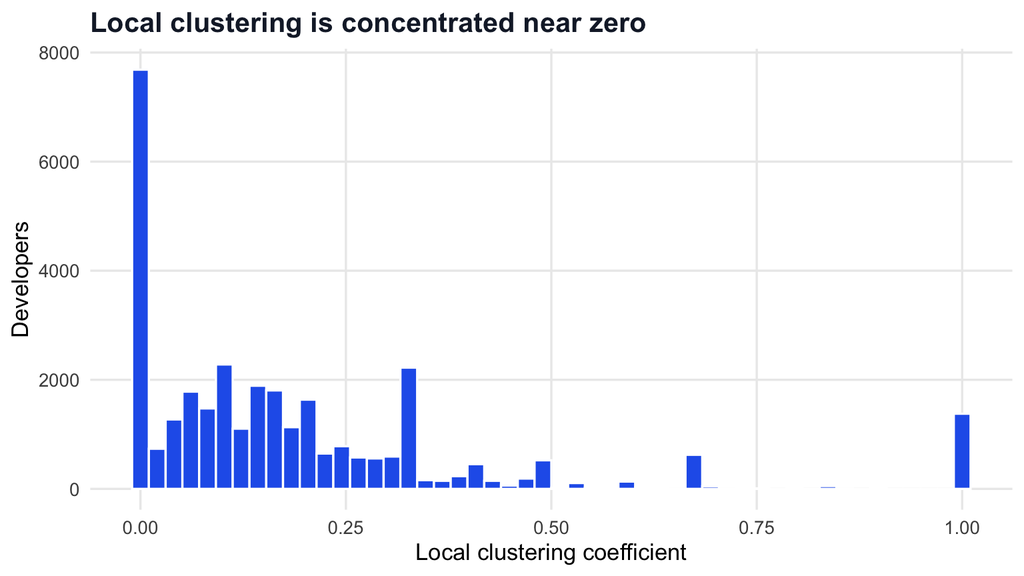

Distribution of non-missing local clustering coefficients.

```r
local_clustering <- transitivity(github_graph, type = "local", isolates = "NaN")

tibble(clustering = local_clustering[is.finite(local_clustering)]) |>
  ggplot(aes(clustering)) +
  geom_histogram(bins = 50, fill = web_color, color = "white") +
  labs(x = "Local clustering coefficient", y = "Developers",
       title = "Local clustering is concentrated near zero")
```

## 3.5 Community detection and graph partitioning

Fast-greedy community detection iteratively joins groups to maximize modularity. Because the precise optimum can change across `igraph` versions, the original report’s cached run is retained for the published result.

```r
# This full-network calculation is available for an exact rerun. It is disabled
# in routine Netlify builds because it is version-sensitive and comparatively
# expensive (roughly tens of seconds on a modern laptop).
fast_greedy_fit <- cluster_fast_greedy(github_graph)

tibble(
  Communities = length(fast_greedy_fit),
  Modularity = modularity(fast_greedy_fit)
)

sort(sizes(fast_greedy_fit), decreasing = TRUE) |> head(10)
```

```r
community_result <- tibble(
  Algorithm = "Fast-greedy",
  Communities = 335,
  Modularity = 0.3957
)

kable(community_result, digits = 4,
      caption = "Community-detection result retained from the original report run.")
```

Community-detection result retained from the original report run.

| Algorithm | Communities | Modularity |
| --- | --- | --- |
| Fast-greedy | 335 | 0.3957 |

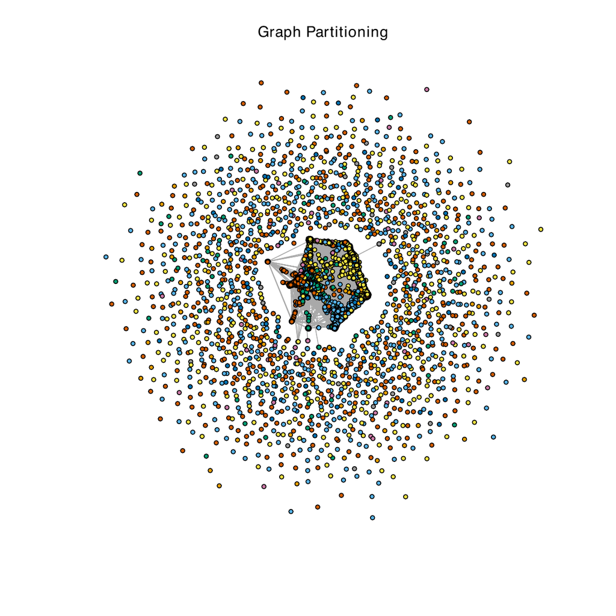

Figure 2: Fast-greedy partition of the GitHub network.

The moderate modularity indicates meaningful community structure, with a prominent central region and many peripheral groups.

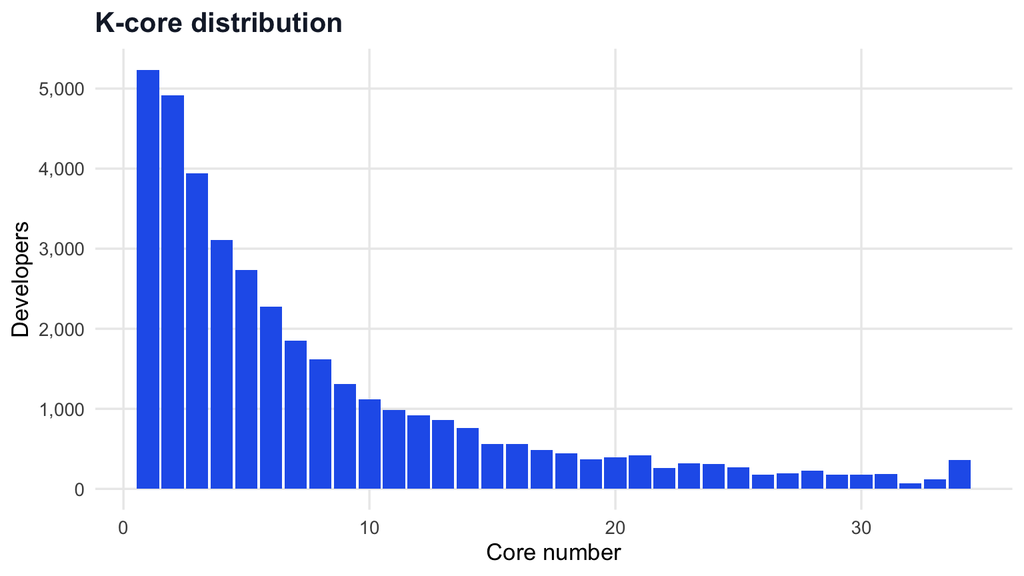

Number of developers assigned to each k-core.

```r
core_distribution <- tibble(core = core_number) |>
  count(core, name = "developers")

ggplot(core_distribution, aes(core, developers)) +
  geom_col(fill = web_color) +
  scale_y_continuous(labels = label_comma()) +
  labs(x = "Core number", y = "Developers", title = "K-core distribution")
```

The maximum core number is 34. High-core developers form a densely connected nucleus, while the lower cores contain the much larger periphery.

## 3.6 Assortativity and mixing patterns

Assortativity measures whether similar nodes preferentially connect. We examine both degree mixing and professional homophily.

```r
degree_assortativity <- assortativity_degree(github_graph, directed = FALSE)
type_assortativity <- assortativity_nominal(
  github_graph,
  # igraph's nominal assortativity implementation expects positive integer
  # category codes, so map the stored 0/1 labels to 1/2.
  types = V(github_graph)$ml_target + 1L,
  directed = FALSE
)

assortativity_table <- tibble(
  Measure = c("Degree", "Job type (homophily)"),
  Value = c(degree_assortativity, type_assortativity),
  Interpretation = c(
    "Mildly disassortative: hubs connect to the periphery",
    "Strongly assortative: the same developer types connect"
  )
)

kable(assortativity_table, digits = 3,
      caption = "Assortativity coefficients.")
```

Assortativity coefficients.

| Measure | Value | Interpretation |
| --- | --- | --- |
| Degree | -0.075 | Mildly disassortative: hubs connect to the periphery |
| Job type (homophily) | 0.378 | Strongly assortative: the same developer types connect |

The degree coefficient of about $-0.075$ supports a hub-and-spoke interpretation. The job-type coefficient of about $0.378$ indicates substantial homophily.

```r
edge_ends <- ends(github_graph, E(github_graph), names = FALSE)
edge_labels <- tibble(
  from = V(github_graph)$ml_target[edge_ends[, 1]],
  to   = V(github_graph)$ml_target[edge_ends[, 2]]
) |>
  mutate(
    pair = case_when(
      from == 0 & to == 0 ~ "Web-Web",
      from == 1 & to == 1 ~ "MLE-MLE",
      TRUE ~ "Web-MLE"
    )
  ) |>
  count(pair, name = "Observed edges")

n_web <- sum(V(github_graph)$ml_target == 0)
n_mle <- sum(V(github_graph)$ml_target == 1)

mixing_probabilities <- tibble(
  pair = c("Web-Web", "Web-MLE", "MLE-MLE"),
  `Possible pairs` = c(choose(n_web, 2), n_web * n_mle, choose(n_mle, 2))
) |>
  left_join(edge_labels, by = "pair") |>
  mutate(`Edge probability` = `Observed edges` / `Possible pairs`) |>
  rename(`Block pair` = pair)

kable(mixing_probabilities, digits = 7, format.args = list(big.mark = ","),
      caption = "Observed edges and possible-pair-adjusted block probabilities.")
```

Observed edges and possible-pair-adjusted block probabilities.

| Block pair | Possible pairs | Observed edges | Edge probability |
| --- | --- | --- | --- |
| Web-Web | 390,894,780 | 224,623 | 0.0005746 |
| Web-MLE | 272,312,179 | 44,696 | 0.0001641 |
| MLE-MLE | 47,419,191 | 19,684 | 0.0004151 |

After controlling for group size, both within-group edge probabilities remain much larger than the Web-MLE probability. Professional homophily is therefore not merely an artifact of the 3:1 class imbalance.

## 3.7 Comparison with random graph models

Random graphs provide controlled null models. Erdős-Rényi preserves the observed density in expectation; the configuration model preserves the degree sequence; Watts-Strogatz emphasizes local clustering and short paths; and Barabási-Albert generates hubs through preferential attachment.

```r
# The original analysis generated each null model at the observed network size.
# This code is kept visible but disabled for fast, reliable web builds.
n <- vcount(github_graph)
m <- ecount(github_graph)
p <- 2 * m / (n * (n - 1))
mean_degree <- mean(degree(github_graph))

er_graph <- sample_gnp(n, p)
configuration_graph <- sample_degseq(degree(github_graph), method = "vl")
watts_strogatz_graph <- sample_smallworld(
  dim = 1, size = n, nei = floor(mean_degree / 2), p = 0.05
)
barabasi_albert_graph <- sample_pa(n, m = round(mean_degree / 2), directed = FALSE)
```

```r
model_comparison <- tribble(
  ~Model, ~Nodes, ~`Mean degree`, ~`SD degree`, ~Transitivity, ~`Average path`,
  "GitHub network",       37700, 15.33, 80.79, 0.0124, 3.24,
  "Erdős-Rényi",         37700, 15.33,  3.92, 0.0004, 4.14,
  "Configuration model", 37700, 15.33, 80.79, 0.0169, 3.34,
  "Watts-Strogatz",      37700, 14.00,  1.17, 0.5052, 4.25,
  "Barabási-Albert",       37700, 16.00, 19.88, 0.0027, 3.65
)

kable(model_comparison, digits = 4, format.args = list(big.mark = ","),
      caption = "Network properties compared with classical random-graph models.")
```

Network properties compared with classical random-graph models.

| Model | Nodes | Mean degree | SD degree | Transitivity | Average path |
| --- | --- | --- | --- | --- | --- |
| GitHub network | 37,700 | 15.33 | 80.79 | 0.0124 | 3.24 |
| Erdős-Rényi | 37,700 | 15.33 | 3.92 | 0.0004 | 4.14 |
| Configuration model | 37,700 | 15.33 | 80.79 | 0.0169 | 3.34 |
| Watts-Strogatz | 37,700 | 14.00 | 1.17 | 0.5052 | 4.25 |
| Barabási-Albert | 37,700 | 16.00 | 19.88 | 0.0027 | 3.65 |

The configuration model comes closest on degree variability and path length, showing how much of the observed structure is explained by the degree sequence. Erdős-Rényi substantially understates clustering, Watts-Strogatz overstates it for these parameters, and the Barabási-Albert model produces hubs but not the full observed degree variability.

## 3.8 Small-world assessment

A network has small-world structure when clustering is much higher than in a comparable random graph while typical path lengths remain similar (Watts and Strogatz 1998). The usual score is

$$\sigma = \frac{C_{\text{obs}}/C_{\text{ER}}}{L_{\text{obs}}/L_{\text{ER}}}.$$

```r
observed_clustering <- 0.0124
er_clustering <- 0.000409
observed_path <- 3.24
er_path <- 4.13

clustering_ratio <- observed_clustering / er_clustering
path_ratio <- observed_path / er_path
small_world_sigma <- clustering_ratio / path_ratio

small_world <- tibble(
  Property = c("Clustering coefficient", "Average path length"),
  GitHub = c(observed_clustering, observed_path),
  `ER mean` = c(er_clustering, er_path),
  Ratio = c(clustering_ratio, path_ratio)
)

kable(small_world, digits = 3,
      caption = "Observed network compared with an Erdős-Rényi baseline.")
```

Observed network compared with an Erdős-Rényi baseline.

| Property | GitHub | ER mean | Ratio |
| --- | --- | --- | --- |
| Clustering coefficient | 0.012 | 0.00 | 30.318 |
| Average path length | 3.240 | 4.13 | 0.785 |

```r
cat("Small-world score (sigma):", round(small_world_sigma, 1))
```

```
Small-world score (sigma): 38.6
```

# 4 Results

The GitHub network is simple, undirected, connected, and sparse. Its degree distribution is highly skewed: most developers have few mutual-follower connections, while a small elite of hubs dominates reach and influence. The network exhibits small-world structure, mild negative degree assortativity, and strong professional homophily. A moderately modular community structure and a maximum 34-core further reveal a dense nucleus surrounded by a much larger periphery.

# 5 Discussion

The results point to a visibility hierarchy. Established developers attract connections from the wider periphery, a pattern compatible with preferential attachment. Bridge-like nodes and high-degree hubs can act as gatekeepers, although an articulation point should not be interpreted as proof that removing a single famous hub would fragment the entire global community in a practically meaningful way. Professional homophily may also limit contact across developer specialties, but the binary Web/MLE label is too coarse to establish the existence of echo chambers by itself.

# 6 Future work

Future analysis should use newer and longitudinal data, especially given the rapid growth of machine learning and generative AI. Richer occupation and activity attributes would provide a more realistic account of developer identity and collaboration. Link prediction could model network growth, while exponential random graph models or scalable latent-space models could test higher-order mechanisms such as triadic closure and attribute homophily.

## References

Csardi, Gabor, and Tamas Nepusz. 2006. “The Igraph Software Package for Complex Network Research.” *InterJournal, Complex Systems* 1695 (5): 1–9. https://igraph.org.

Hague, Danny. 2022. “Global GitHub: Mapping the Utilization of Open Source Software by Organizations.” Data Snapshot. Center for Security; Emerging Technology, Georgetown University. https://cset.georgetown.edu/publication/global-github-mapping-the-utilization-of-open-source-software-by-organizations/.

Kolaczyk, Eric D., and Gábor Csárdi. 2020. *Statistical Analysis of Network Data with R*. Use r! Springer Cham. https://doi.org/10.1007/978-3-030-44129-6.

Rozemberczki, Benedek, Carl Allen, and Rik Sarkar. 2021. “MUSAE: Multi-Scale Attributed Node Embedding.” *Applied Network Science* 6 (1): 1–21. https://doi.org/10.1007/s41109-021-00382-x.

Watts, Duncan J., and Steven H. Strogatz. 1998. “Collective Dynamics of ‘Small-World’ Networks.” *Nature* 393 (6684): 440–42. https://doi.org/10.1038/30918.